# Algorithm Bias

Student ID: 24292215

Student Name: Lucas Sipos George

## Task 1

For task one, I have loaded the Appendicitis dataset, had a look over the majority and minority class, assessed the bias of k-NN and Decision Tree classifiers trained on this dataset and also had a look over the possible solution for improving the overall accuracy.

```python
import pandas as pd
from imblearn.over_sampling import ADASYN, SMOTE, RandomOverSampler, BorderlineSMOTE, SVMSMOTE
from imblearn.under_sampling import ClusterCentroids, InstanceHardnessThreshold, RandomUnderSampler, AllKNN, \
    CondensedNearestNeighbour, EditedNearestNeighbours, RepeatedEditedNearestNeighbours, NearMiss, \
    NeighbourhoodCleaningRule, OneSidedSelection, TomekLinks
from imblearn.combine import SMOTEENN, SMOTETomek
from sklearn.neighbors import KNeighborsClassifier
from sklearn.tree import DecisionTreeClassifier
from sklearn.preprocessing import LabelEncoder, StandardScaler
from sklearn.model_selection import train_test_split, cross_val_score
from sklearn.metrics import accuracy_score, confusion_matrix, classification_report, roc_auc_score, \
    ConfusionMatrixDisplay, roc_curve, recall_score
from sklearn.feature_selection import SelectKBest, mutual_info_classif
from matplotlib import pyplot as plt
import numpy as np
```

```python
df_appendicitis = pd.read_csv("appendicitis.csv", index_col=0)
df_appendicitis.sort_index(inplace=True)
df_appendicitis.head()
```

|  | Age | BMI | Sex | Height | Weight | Length_of_Stay | Alvarado_Score | Paedriatic_Appendicitis_Score | Appendix_on_US | Migratory_Pain | Lower_Right_Abd_Pain | Contralateral_Rebound_Tenderness | Coughing_Pain | Nausea | Loss_of_Appetite | Body_Temperature | WBC_Count | Dysuria | Diagnosis |
| --- | --- | --- | --- | --- | --- | --- | --- | --- | --- | --- | --- | --- | --- | --- | --- | --- | --- | --- | --- |
| 0 | 12.68 | 16.9 | 1 | 148.0 | 37.0 | 3.0 | 4.0 | 3.0 | 1 | 0 | 1 | 1 | 0 | 0 | 1 | 37.0 | 7.7 | 0 | appendicitis |
| 1 | 14.10 | 31.9 | 0 | 147.0 | 69.5 | 2.0 | 5.0 | 4.0 | 0 | 1 | 1 | 1 | 0 | 0 | 1 | 36.9 | 8.1 | 1 | no appendicitis |
| 2 | 14.14 | 23.3 | 1 | 163.0 | 62.0 | 4.0 | 5.0 | 3.0 | 0 | 0 | 1 | 1 | 0 | 0 | 0 | 36.6 | 13.2 | 0 | no appendicitis |
| 3 | 16.37 | 20.6 | 1 | 165.0 | 56.0 | 3.0 | 7.0 | 6.0 | 0 | 1 | 1 | 0 | 0 | 1 | 1 | 36.0 | 11.4 | 1 | no appendicitis |
| 4 | 11.08 | 16.9 | 1 | 163.0 | 45.0 | 3.0 | 5.0 | 6.0 | 1 | 0 | 1 | 1 | 1 | 1 | 1 | 36.9 | 8.1 | 0 | appendicitis |

```python
n = df_appendicitis.shape[0]
app, no_app = df_appendicitis["Diagnosis"].value_counts().items()
print(f"Samples: {n}")
print(f"Majority: {app[0]}, {app[1]}")
print(f"Minority: {no_app[0]}, {no_app[1]}")
```

```
Samples: 631
Majority: appendicitis, 390
Minority: no appendicitis, 241
```

From the class distribution we can see that the majority class is appendicitis positive and the minority is appendicitis negative.

```python
knn = KNeighborsClassifier()
dt = DecisionTreeClassifier()
classifiers = [knn, dt]
```

Wrote a function which will help with the data visualisation according to the classifier in use.

```python
def visualisation_classifiers(x_train_, x_test_, y_train_, y_test_):
    fig = plt.figure(figsize=(8, 5))
    roc_curve_values = []
    for i, classifier in enumerate(classifiers, start=1):
        trained_classifier = classifier.fit(x_train_, y_train_)
        y_dash = trained_classifier.predict(x_test_)
        yN_dash = trained_classifier.predict_proba(x_test_)

        acc_score = accuracy_score(y_test_, y_dash)
        confusion = confusion_matrix(y_test_, y_dash)
        classifier_name = classifier.__class__.__name__
        report = classification_report(y_test_, y_dash, target_names=["Appendicitis", "No Appendicitis"])
        scores = cross_val_score(classifier, X, y, cv=6, verbose=0, n_jobs=-1)
        fpr, tpr, _ = roc_curve(y_test_, yN_dash[:, 1])
        roc_auc = roc_auc_score(y_test_, yN_dash[:, 1])
        roc_curve_values.append([fpr, tpr, roc_auc])
        print(classifier_name)
        print(f"Accuracy: {acc_score}")
        print(f"Confusion Matrix:\n{confusion}")
        print(f"Report:\n{report}")
        print(f"6x CV Accuracy: {scores.mean():.2f}", end="\n" * 3)
        disp = ConfusionMatrixDisplay(confusion, display_labels=["App", "No App"])
        fg = fig.add_subplot(1, 2, i)
        disp.plot(ax=fg)
        plt.title(classifier_name)
    fig.tight_layout()
    plt.show()
    fig = plt.figure(figsize=(5.5, 5))
    fg = fig.add_subplot(1, 1, 1)
    fg.plot(roc_curve_values[0][0], roc_curve_values[0][1], color="lime", lw=2,
            label=f"ROC kNN (area = {roc_curve_values[0][2]:0.2f})")
    fg.plot(roc_curve_values[1][0], roc_curve_values[1][1], color="cyan", lw=2,
            label=f"ROC DT (area = {roc_curve_values[1][2]:0.2f})")
    fg.plot([0, 1], [0, 1], color="pink", lw=2, linestyle="--")
    plt.xlim([0.0, 1.0])
    plt.ylim([0.0, 1.0])
    plt.xlabel("False Positive Rate")
    plt.ylabel("True Positive Rate")
    plt.title("ROC Analysis for Appendicitis Prediction data")
    plt.legend(loc="lower right")
    fig.tight_layout()
    plt.show()
```

```python
y = df_appendicitis.pop("Diagnosis").values
X = df_appendicitis.values

encoder = LabelEncoder()
y = encoder.fit_transform(y)
X_train, X_test, y_train, y_test = train_test_split(X, y, test_size=1 / 3, random_state=42)
```

```
KNeighborsClassifier
Accuracy: 0.6824644549763034
Confusion Matrix:
[[103  30]
 [ 37  41]]
Report:
                 precision    recall  f1-score   support

   Appendicitis       0.74      0.77      0.75       133
No Appendicitis       0.58      0.53      0.55        78

       accuracy                           0.68       211
      macro avg       0.66      0.65      0.65       211
   weighted avg       0.68      0.68      0.68       211

6x CV Accuracy: 0.66


DecisionTreeClassifier
Accuracy: 0.7156398104265402
Confusion Matrix:
[[98 35]
 [25 53]]
Report:
                 precision    recall  f1-score   support

   Appendicitis       0.80      0.74      0.77       133
No Appendicitis       0.60      0.68      0.64        78

       accuracy                           0.72       211
      macro avg       0.70      0.71      0.70       211
   weighted avg       0.72      0.72      0.72       211

6x CV Accuracy: 0.76
```

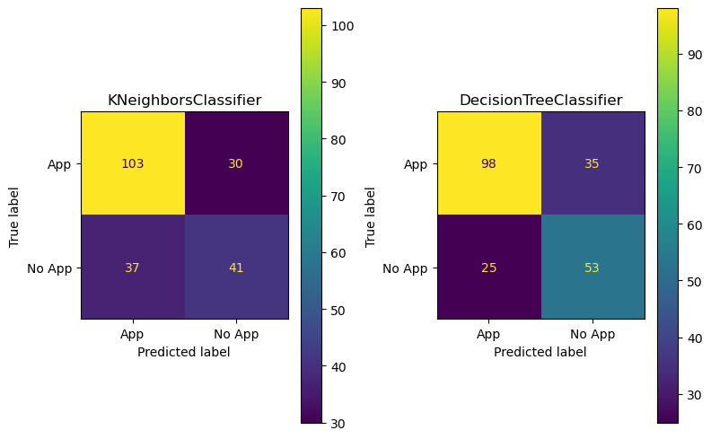

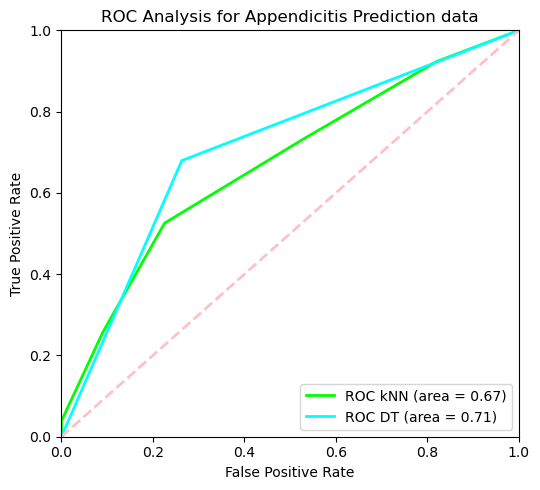

```python
visualisation_classifiers(X_train, X_test, y_train, y_test)
```

```python
classifiers[1] = DecisionTreeClassifier(max_depth=3, criterion='entropy')
scaler = StandardScaler().fit(X)
X_scaled = scaler.transform(X)
X_train_s, X_test_s, y_train_s, y_test_s = train_test_split(X_scaled, y, test_size=1 / 3, random_state=42)
```

```
KNeighborsClassifier
Accuracy: 0.7772511848341233
Confusion Matrix:
[[114  19]
 [ 28  50]]
Report:
                 precision    recall  f1-score   support

   Appendicitis       0.80      0.86      0.83       133
No Appendicitis       0.72      0.64      0.68        78

       accuracy                           0.78       211
      macro avg       0.76      0.75      0.75       211
   weighted avg       0.77      0.78      0.77       211

6x CV Accuracy: 0.66


DecisionTreeClassifier
Accuracy: 0.8293838862559242
Confusion Matrix:
[[122  11]
 [ 25  53]]
Report:
                 precision    recall  f1-score   support

   Appendicitis       0.83      0.92      0.87       133
No Appendicitis       0.83      0.68      0.75        78

       accuracy                           0.83       211
      macro avg       0.83      0.80      0.81       211
   weighted avg       0.83      0.83      0.83       211

6x CV Accuracy: 0.82
```

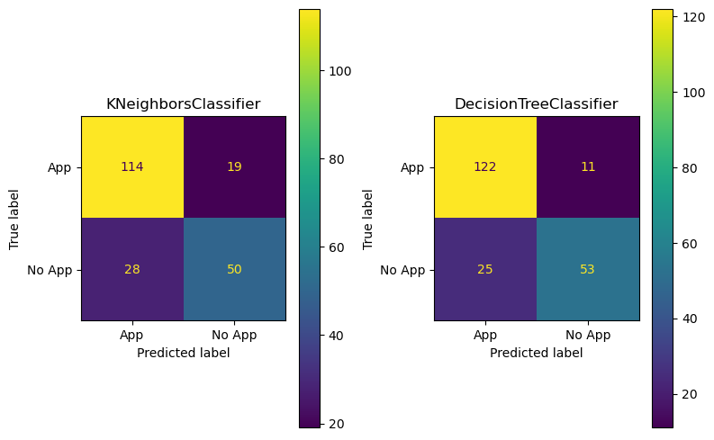

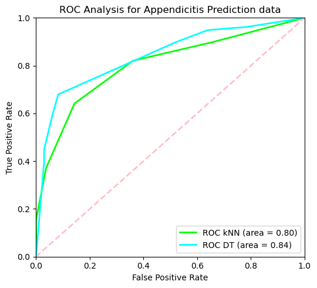

```python
visualisation_classifiers(X_train_s, X_test_s, y_train_s, y_test_s)
```

```python
i_scores = mutual_info_classif(X_train_s, y_train_s)

mi = dict()
for i, j in zip(df_appendicitis.columns, i_scores):
    mi[i] = j

df_i_gain = pd.DataFrame.from_dict(mi, orient='index', columns=['I_Gain'])
df_i_gain.sort_values(by=['I_Gain'], ascending=False, inplace=True)
df_i_gain.head(7)
```

|  | I_Gain |
| --- | --- |
| Length_of_Stay | 0.153315 |
| WBC_Count | 0.127729 |
| Appendix_on_US | 0.113192 |
| Paedriatic_Appendicitis_Score | 0.070269 |
| Body_Temperature | 0.070221 |
| Alvarado_Score | 0.068105 |
| Weight | 0.053488 |

```python
for classifier in classifiers:
    acc_scores = []
    for kk in range(1, X_scaled.shape[1] + 1):
        FS_trans = SelectKBest(mutual_info_classif, k=kk).fit(X_train_s, y_train_s)
        X_train_s_new = FS_trans.transform(X_train_s)
        X_test_s_new = FS_trans.transform(X_test_s)
        seg = classifier.fit(X_train_s_new, y_train_s)
        y_dash = seg.predict(X_test_s_new)
        acc = accuracy_score(y_test_s, y_dash)
        acc_scores.append(acc)
    df_i_gain[f"Accuracy_{classifier.__class__.__name__[0]}"] = acc_scores
df_i_gain.head(7)
```

|  | I_Gain | Accuracy_K | Accuracy_D |
| --- | --- | --- | --- |
| Length_of_Stay | 0.153315 | 0.616114 | 0.625592 |
| WBC_Count | 0.127729 | 0.777251 | 0.691943 |
| Appendix_on_US | 0.113192 | 0.658768 | 0.706161 |
| Paedriatic_Appendicitis_Score | 0.070269 | 0.781991 | 0.829384 |
| Body_Temperature | 0.070221 | 0.796209 | 0.829384 |
| Alvarado_Score | 0.068105 | 0.805687 | 0.829384 |
| Weight | 0.053488 | 0.805687 | 0.829384 |

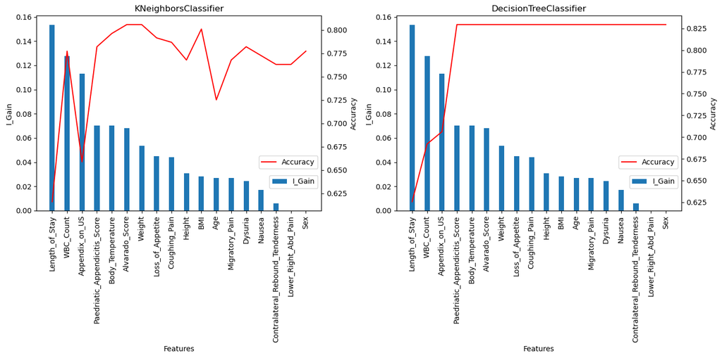

```python
fig = plt.figure(figsize=(14, 7))
for i, classifier in enumerate(classifiers, start=1):
    fg = fig.add_subplot(1, 2, i)
    fg2 = fg.twinx()
    fg.bar(df_i_gain.index, df_i_gain["I_Gain"], label="I_Gain", width=.35)
    fg2.plot(df_i_gain.index, df_i_gain[f"Accuracy_{classifier.__class__.__name__[0]}"], color="red", label="Accuracy")
    fg.set_xticks(list(df_i_gain.index), list(df_i_gain.index), rotation=90)
    fg.set_title(classifier.__class__.__name__)
    fg.set_xlabel('Features')
    fg.set_ylabel('I_Gain')
    fg2.set_ylabel('Accuracy')
    fg.legend(bbox_to_anchor=(1, 0.2))
    fg2.legend(bbox_to_anchor=(1, 0.3))
fig.tight_layout()
plt.show()
```

```python
first_max, first_max_index = 0, 0
for index, info in enumerate(df_i_gain.head(12).iterrows()):
    if first_max < info[1]["Accuracy_K"]:
        first_max_index = index
        first_max = info[1]["Accuracy_K"]
features = [df_i_gain.index.values[:first_max_index + 1], df_i_gain.index.values[:4]]
print(features)
```

```
[array(['Length_of_Stay', 'WBC_Count', 'Appendix_on_US',
       'Paedriatic_Appendicitis_Score', 'Body_Temperature',
       'Alvarado_Score'], dtype=object), array(['Length_of_Stay', 'WBC_Count', 'Appendix_on_US',
       'Paedriatic_Appendicitis_Score'], dtype=object)]
```

```python
X_selected_k = df_appendicitis[features[0]].values
X_selected_d = df_appendicitis[features[1]].values
X_all = [X_selected_k, X_selected_d]

scaler_k = StandardScaler().fit(X_selected_k)
scaler_d = StandardScaler().fit(X_selected_d)
scaler_all = [scaler_k, scaler_d]

X_scaled_k = scaler_k.transform(X_selected_k)
X_scaled_d = scaler_d.transform(X_selected_d)
X_scaled_all = [X_scaled_k, X_scaled_d]

X_train_s_k, X_test_s_k, y_train_s_k, y_test_s_k = train_test_split(X_scaled_k, y, test_size=1 / 3, random_state=42)
X_train_s_d, X_test_s_d, y_train_s_d, y_test_s_d = train_test_split(X_scaled_d, y, test_size=1 / 3, random_state=42)
train_test_all = [[X_train_s_k, X_test_s_k, y_train_s_k, y_test_s_k],
                  [X_train_s_d, X_test_s_d, y_train_s_d, y_test_s_d]]
```

```
KNeighborsClassifier
Accuracy: 0.7914691943127962
Confusion Matrix:
[[113  20]
 [ 24  54]]
Report:
                 precision    recall  f1-score   support

   Appendicitis       0.82      0.85      0.84       133
No Appendicitis       0.73      0.69      0.71        78

       accuracy                           0.79       211
      macro avg       0.78      0.77      0.77       211
   weighted avg       0.79      0.79      0.79       211

6x CV Accuracy: 0.79


DecisionTreeClassifier
Accuracy: 0.8199052132701422
Confusion Matrix:
[[119  14]
 [ 24  54]]
Report:
                 precision    recall  f1-score   support

   Appendicitis       0.83      0.89      0.86       133
No Appendicitis       0.79      0.69      0.74        78

       accuracy                           0.82       211
      macro avg       0.81      0.79      0.80       211
   weighted avg       0.82      0.82      0.82       211

6x CV Accuracy: 0.80
```

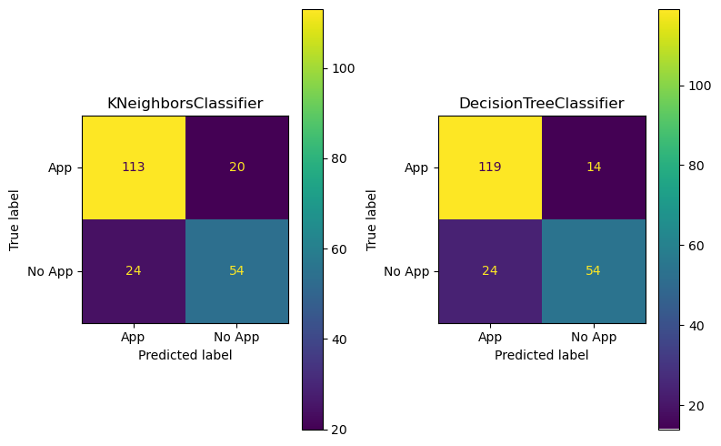

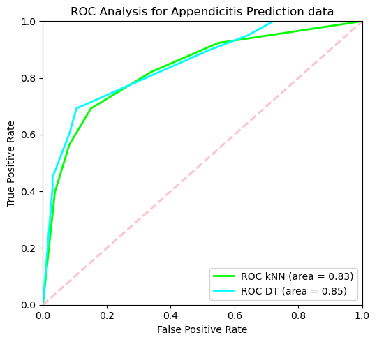

```python
fig = plt.figure(figsize=(8, 5))
roc_curve_values = []
for i, classifier in enumerate(classifiers):
    trained_classifier = classifier.fit(train_test_all[i][0], train_test_all[i][2])
    y_dash = trained_classifier.predict(train_test_all[i][1])
    yN_dash = trained_classifier.predict_proba(train_test_all[i][1])

    acc_score = accuracy_score(train_test_all[i][3], y_dash)
    confusion = confusion_matrix(train_test_all[i][3], y_dash)
    classifier_name = classifier.__class__.__name__
    report = classification_report(train_test_all[i][3], y_dash, target_names=["Appendicitis", "No Appendicitis"])
    scores = cross_val_score(classifier, X_scaled_all[i], y, cv=6, verbose=0, n_jobs=-1)
    fpr, tpr, _ = roc_curve(train_test_all[i][3], yN_dash[:, 1])
    roc_auc = roc_auc_score(train_test_all[i][3], yN_dash[:, 1])
    roc_curve_values.append([fpr, tpr, roc_auc])
    print(classifier_name)
    print(f"Accuracy: {acc_score}")
    print(f"Confusion Matrix:\n{confusion}")
    print(f"Report:\n{report}")
    print(f"6x CV Accuracy: {scores.mean():.2f}", end="\n" * 3)
    disp = ConfusionMatrixDisplay(confusion, display_labels=["App", "No App"])
    fg = fig.add_subplot(1, 2, i + 1)
    disp.plot(ax=fg)
    plt.title(classifier_name)
fig.tight_layout()
plt.show()
fig = plt.figure(figsize=(5.5, 5))
fg = fig.add_subplot(1, 1, 1)
fg.plot(roc_curve_values[0][0], roc_curve_values[0][1], color="lime", lw=2,
        label=f"ROC kNN (area = {roc_curve_values[0][2]:0.2f})")
fg.plot(roc_curve_values[1][0], roc_curve_values[1][1], color="cyan", lw=2,
        label=f"ROC DT (area = {roc_curve_values[1][2]:0.2f})")
fg.plot([0, 1], [0, 1], color="pink", lw=2, linestyle="--")
plt.xlim([0.0, 1.0])
plt.ylim([0.0, 1.0])
plt.xlabel("False Positive Rate")
plt.ylabel("True Positive Rate")
plt.title("ROC Analysis for Appendicitis Prediction data")
plt.legend(loc="lower right")
fig.tight_layout()
plt.show()
```

## Study conducted on the majority of the techniques

This part is more so that everyone can see how I found out which technique I needed to use in order to get rid of the imbalanced data. This is done on normalized data and encoded labels, but I didn't do any tweaking to the classifiers parameters.

```python
colors = ["red", "yellow", "green", "blue", "orange", "indigo", "violet", "pink", "purple", "brown", "gray", "black",
          "white", "silver", "gold"]
```

```python
knn = KNeighborsClassifier()
dt = DecisionTreeClassifier()
classifiers = [knn, dt]
```

Implemented a general function for visualising data and testing it for multiple number of iterations

```python
def visualisation(classifiers, techniques, row_subplot, column_subplot, no_iterations=25):
    """
    For every classifier it tests over a number of iterations the given techniques
    :param classifiers: list of classifiers
    :param techniques: list of lists containing object technique and name
    :param row_subplot: int for rows in subplot
    :param column_subplot: int for columns in subplot
    :param no_iterations: int for number of iterations
    :return: None
    """
    # loop through classifiers
    for classifier in classifiers:
        # figure size which contains the subplots
        fig = plt.figure(figsize=(14, 5))
        # accuracies for every iteration of every technique
        acc_scores = [[] for _ in range(len(techniques))]
        # same as before but recall scores
        recall_scores = [[] for _ in range(len(techniques))]
        # same as before but confusion matrices
        confusion_matrices = [[] for _ in range(len(techniques))]
        # all test data which is the same for all the techniques
        y_tests = []
        # every techniques results for every iteration
        y_dash_all = [[] for _ in range(len(techniques))]
        for _ in range(no_iterations):
            # split the data random every time
            X_train, X_test, y_train, y_test = train_test_split(X_scaled, y, test_size=1 / 3,
                                                                random_state=np.random.randint(1000))
            y_tests.extend(y_test)
            for i, technique in enumerate(techniques):
                # make a copy so it doesn't get mixed up
                X_train_copy, y_train_copy = X_train, y_train
                # the first index has None as first parameter because it doesn't use a technique
                if i != 0:
                    X_train_copy, y_train_copy = technique[0].fit_resample(X_train_copy, y_train_copy)
                trained_classifier = classifier.fit(X_train_copy, y_train_copy)
                y_dash = trained_classifier.predict(X_test)
                y_dash_all[i].extend(y_dash)

                acc_scores[i].append(accuracy_score(y_test, y_dash))
                recall_scores[i].append(recall_score(y_test, y_dash, average=None))
                confusion_matrices[i].append(confusion_matrix(y_test, y_dash))

        for i, technique in enumerate(techniques):
            classifier_technique = f"{'DT' if classifier.__class__.__name__[0] == 'D' else 'KNN'} using " + \
                                   technique[1]
            # axis = 0 is not necessary, add every techniques' confusion matrix with each other
            confusion = np.sum(confusion_matrices[i], axis=0)
            # make a report on the test results of every technique
            report = classification_report(y_tests, y_dash_all[i], target_names=["Appendicitis", "No Appendicitis"])
            print(classifier_technique)
            print(f"Accuracy: {np.mean(acc_scores[i])}")
            print(f"Recall: {np.mean(recall_scores[i])}")
            print(f"Confusion Matrix:\n{confusion}")
            print(f"Report:\n{report[:171]}", end="\n" * 3)
            fg = fig.add_subplot(row_subplot, column_subplot, i + 1)
            disp = ConfusionMatrixDisplay(confusion, display_labels=["App", "No App"])
            disp.plot(ax=fg)
            plt.title(classifier_technique)

        fig.tight_layout()
        plt.show()
```

### Over-sampling

```python
techniques_over_sampling = [[None, "Nothing"],
                            [RandomOverSampler(random_state=42, sampling_strategy="minority"), "Random"],
                            [SMOTE(random_state=42, sampling_strategy="minority"), "SMOTE"],
                            [ADASYN(random_state=42, sampling_strategy="minority"), "ADASYN"],
                            [BorderlineSMOTE(random_state=42, sampling_strategy="minority"), "BorderlineSMOTE"],
                            [SVMSMOTE(random_state=42, sampling_strategy="minority"), "SVMSMOTE"]]
```

```
KNN using Nothing
Accuracy: 0.7516587677725117
Recall: 0.7200443689239843
Confusion Matrix:
[[2789  460]
 [ 850 1176]]
Report:
                 precision    recall  f1-score   support

   Appendicitis       0.77      0.86      0.81      3249
No Appendicitis       0.72      0.58      0.64      2026


KNN using Random
Accuracy: 0.7237914691943128
Recall: 0.7171387991540124
Confusion Matrix:
[[2424  825]
 [ 632 1394]]
Report:
                 precision    recall  f1-score   support

   Appendicitis       0.79      0.75      0.77      3249
No Appendicitis       0.63      0.69      0.66      2026


KNN using SMOTE
Accuracy: 0.7220853080568722
Recall: 0.7199770926733795
Confusion Matrix:
[[2368  881]
 [ 585 1441]]
Report:
                 precision    recall  f1-score   support

   Appendicitis       0.80      0.73      0.76      3249
No Appendicitis       0.62      0.71      0.66      2026


KNN using ADASYN
```

[output cut: 21 more lines]

```
   Appendicitis       0.81      0.68      0.74      3249
No Appendicitis       0.60      0.74      0.66      2026


KNN using SVMSMOTE
Accuracy: 0.7228436018957346
Recall: 0.7205420363568343
Confusion Matrix:
[[2377  872]
 [ 590 1436]]
Report:
                 precision    recall  f1-score   support

   Appendicitis       0.80      0.73      0.76      3249
No Appendicitis       0.62      0.71      0.66      2026
```

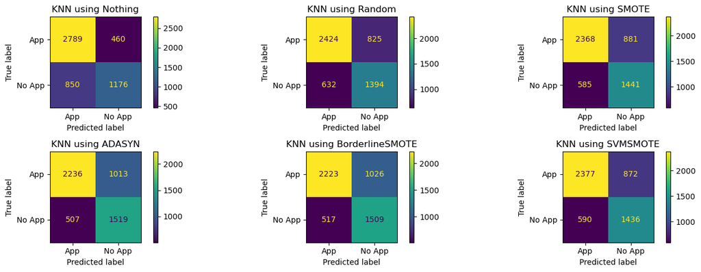

```
DT using Nothing
Accuracy: 0.7662559241706162
Recall: 0.7571939634129677
Confusion Matrix:
[[2599  655]
 [ 578 1443]]
Report:
                 precision    recall  f1-score   support

   Appendicitis       0.82      0.80      0.81      3254
No Appendicitis       0.69      0.71      0.70      2021


DT using Random
Accuracy: 0.7681516587677725
Recall: 0.7554675619211961
Confusion Matrix:
[[2645  609]
 [ 614 1407]]
Report:
                 precision    recall  f1-score   support

   Appendicitis       0.81      0.81      0.81      3254
No Appendicitis       0.70      0.70      0.70      2021


DT using SMOTE
Accuracy: 0.7605687203791469
Recall: 0.7516781138185147
Confusion Matrix:
[[2578  676]
 [ 587 1434]]
Report:
                 precision    recall  f1-score   support

   Appendicitis       0.81      0.79      0.80      3254
No Appendicitis       0.68      0.71      0.69      2021


DT using ADASYN
```

[output cut: 21 more lines]

```
   Appendicitis       0.82      0.78      0.80      3254
No Appendicitis       0.67      0.72      0.69      2021


DT using SVMSMOTE
Accuracy: 0.7700473933649289
Recall: 0.7609513778174876
Confusion Matrix:
[[2603  651]
 [ 562 1459]]
Report:
                 precision    recall  f1-score   support

   Appendicitis       0.82      0.80      0.81      3254
No Appendicitis       0.69      0.72      0.71      2021
```

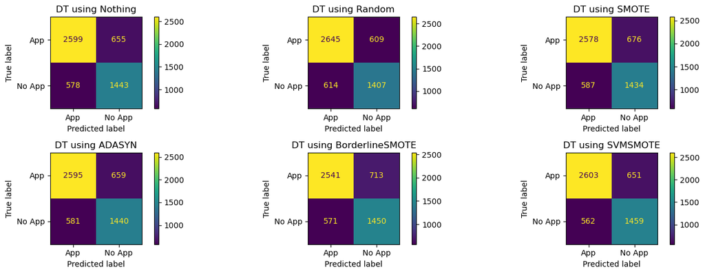

```python
visualisation(classifiers, techniques_over_sampling, 2, 3)
```

**kNN** – ADASYN is the best over-sampling method, BorderlineSMOTE is almost as good as ADASYN, but when I ran the code, ADASYN was a little bit better than BorderlineSMOTE, so I will be choosing ADASYN for parameter tweaking in the next task.

**DT** – ADASYN, BorderlineSMOTE, SVMSMOTE are the top 3 best techniques, but the problem is that none of them are good, hence not choosing any of them later on

### Under-sampling

```python
techniques_under_sampling = [[None, "Nothing"], [RandomUnderSampler(random_state=42), "Random"],
                             [ClusterCentroids(random_state=42), "ClusterCentroids"],
                             [InstanceHardnessThreshold(random_state=42), "HardnessThreshold"], [AllKNN(), "AllKNN"],
                             [CondensedNearestNeighbour(random_state=42), "CNN"], [EditedNearestNeighbours(), "ENN"],
                             [RepeatedEditedNearestNeighbours(), "RENN"], [NearMiss(), "NearMiss"],
                             [NeighbourhoodCleaningRule(), "NCleaningRule"],
                             [OneSidedSelection(random_state=42), "OneSidedSelection"],
                             [TomekLinks(), "TomekLinks"]]
```

```
KNN using Nothing
Accuracy: 0.740473933649289
Recall: 0.7111009638928557
Confusion Matrix:
[[2729  517]
 [ 852 1177]]
Report:
                 precision    recall  f1-score   support

   Appendicitis       0.76      0.84      0.80      3246
No Appendicitis       0.69      0.58      0.63      2029


KNN using Random
Accuracy: 0.7260663507109005
Recall: 0.7232574989811252
Confusion Matrix:
[[2388  858]
 [ 587 1442]]
Report:
                 precision    recall  f1-score   support

   Appendicitis       0.80      0.74      0.77      3246
No Appendicitis       0.63      0.71      0.67      2029


KNN using ClusterCentroids
Accuracy: 0.7300473933649289
Recall: 0.7273743172128065
Confusion Matrix:
[[2403  843]
 [ 581 1448]]
Report:
                 precision    recall  f1-score   support

   Appendicitis       0.81      0.74      0.77      3246
No Appendicitis       0.63      0.71      0.67      2029


KNN using HardnessThreshold
```

[output cut: 99 more lines]

```
   Appendicitis       0.78      0.79      0.78      3246
No Appendicitis       0.66      0.64      0.65      2029


KNN using TomekLinks
Accuracy: 0.7330805687203794
Recall: 0.7150673153948697
Confusion Matrix:
[[2581  665]
 [ 743 1286]]
Report:
                 precision    recall  f1-score   support

   Appendicitis       0.78      0.80      0.79      3246
No Appendicitis       0.66      0.63      0.65      2029
```

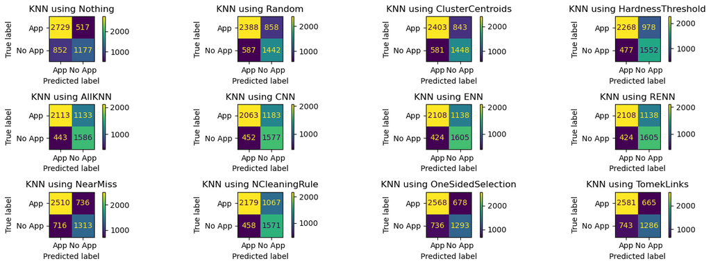

```
DT using Nothing
Accuracy: 0.7711848341232228
Recall: 0.761378424590917
Confusion Matrix:
[[2603  623]
 [ 584 1465]]
Report:
                 precision    recall  f1-score   support

   Appendicitis       0.82      0.81      0.81      3226
No Appendicitis       0.70      0.71      0.71      2049


DT using Random
Accuracy: 0.7509004739336494
Recall: 0.751689520647865
Confusion Matrix:
[[2412  814]
 [ 500 1549]]
Report:
                 precision    recall  f1-score   support

   Appendicitis       0.83      0.75      0.79      3226
No Appendicitis       0.66      0.76      0.70      2049


DT using ClusterCentroids
Accuracy: 0.7446445497630333
Recall: 0.7502583472493963
Confusion Matrix:
[[2342  884]
 [ 463 1586]]
Report:
                 precision    recall  f1-score   support

   Appendicitis       0.83      0.73      0.78      3226
No Appendicitis       0.64      0.77      0.70      2049


DT using HardnessThreshold
```

[output cut: 99 more lines]

```
   Appendicitis       0.82      0.79      0.80      3226
No Appendicitis       0.68      0.73      0.71      2049


DT using TomekLinks
Accuracy: 0.7649289099526067
Recall: 0.7596338508536643
Confusion Matrix:
[[2544  682]
 [ 558 1491]]
Report:
                 precision    recall  f1-score   support

   Appendicitis       0.82      0.79      0.80      3226
No Appendicitis       0.69      0.73      0.71      2049
```

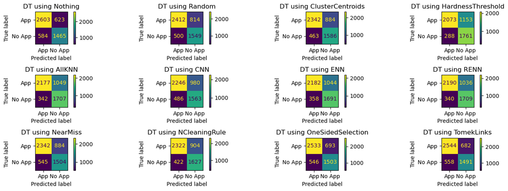

```python
visualisation(classifiers, techniques_under_sampling, 3, 4)
```

**kNN** – HardnessThreshold is the best out of them, in my opinion none of them are as effective as I would like them to be, but maybe after some parameter tweaking everything will be fine.

**DT** – Here we can see that a lot of the techniques are very good but some reason Random is the best one. Some honorable mentions: ClusterCentroids, NearMiss, NCleaningRule, OneSidedSelection, TomekLinks.

### Combined under-over-sampling

```python
results_under_over_s = [[X_train, y_train, "Nothing"]]

X_resampled, y_resampled = SMOTEENN(random_state=42).fit_resample(X_train, y_train)
results_under_over_s.append([X_resampled, y_resampled, ""])

X_resampled, y_resampled = SMOTETomek(random_state=42).fit_resample(X_train, y_train)
results_under_over_s.append([X_resampled, y_resampled, "SMOTETomek"])
```

```python
techniques_combined = [[None, "Nothing"], [SMOTEENN(random_state=42), "SMOTEENN"],
                       [SMOTETomek(random_state=42), "SMOTETomek"]]
```

```
KNN using Nothing
Accuracy: 0.7495734597156398
Recall: 0.7205018620512802
Confusion Matrix:
[[2765  521]
 [ 800 1189]]
Report:
                 precision    recall  f1-score   support

   Appendicitis       0.78      0.84      0.81      3286
No Appendicitis       0.70      0.60      0.64      1989


KNN using SMOTEENN
Accuracy: 0.7254976303317536
Recall: 0.7350975499131033
Confusion Matrix:
[[2286 1000]
 [ 448 1541]]
Report:
                 precision    recall  f1-score   support

   Appendicitis       0.84      0.70      0.76      3286
No Appendicitis       0.61      0.77      0.68      1989


KNN using SMOTETomek
Accuracy: 0.717345971563981
Recall: 0.715859855547025
Confusion Matrix:
[[2373  913]
 [ 578 1411]]
Report:
                 precision    recall  f1-score   support

   Appendicitis       0.80      0.72      0.76      3286
No Appendicitis       0.61      0.71      0.65      1989
```

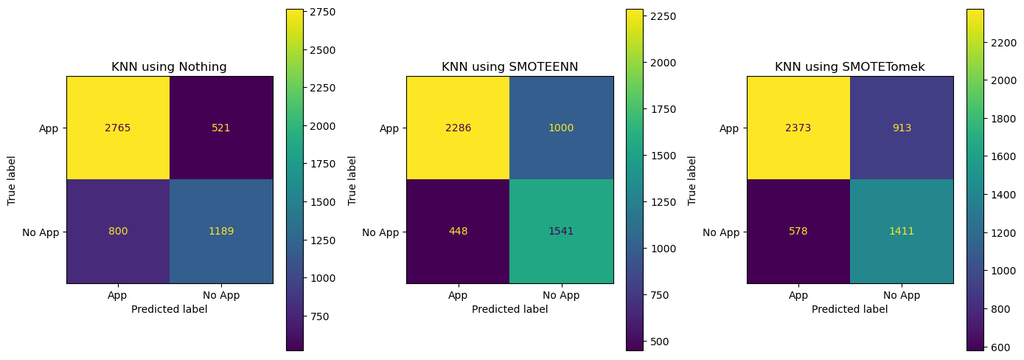

```
DT using Nothing
Accuracy: 0.7647393364928909
Recall: 0.7511662504358116
Confusion Matrix:
[[2634  614]
 [ 627 1400]]
Report:
                 precision    recall  f1-score   support

   Appendicitis       0.81      0.81      0.81      3248
No Appendicitis       0.70      0.69      0.69      2027


DT using SMOTEENN
Accuracy: 0.7683412322274883
Recall: 0.7626211735822526
Confusion Matrix:
[[2560  688]
 [ 534 1493]]
Report:
                 precision    recall  f1-score   support

   Appendicitis       0.83      0.79      0.81      3248
No Appendicitis       0.68      0.74      0.71      2027


DT using SMOTETomek
Accuracy: 0.7692890995260665
Recall: 0.7592558992017451
Confusion Matrix:
[[2611  637]
 [ 580 1447]]
Report:
                 precision    recall  f1-score   support

   Appendicitis       0.82      0.80      0.81      3248
No Appendicitis       0.69      0.71      0.70      2027
```

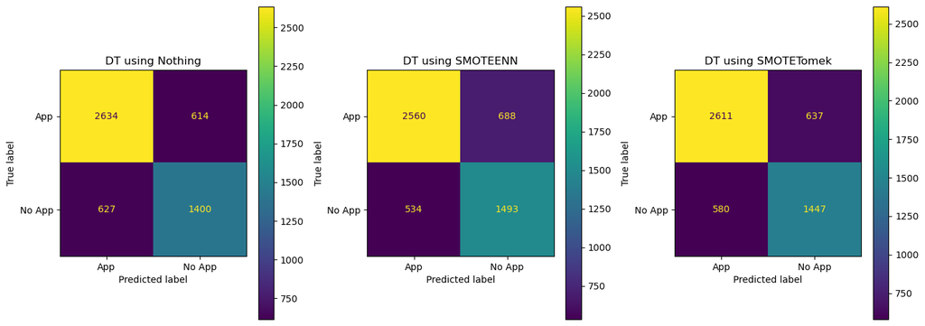

```python
visualisation(classifiers, techniques_combined, 1, 3)
```

**kNN** – SMOTETomek is the clear winner demonstrating a very good balance in the recall statistics, opposed to SMOTEENN.

**DT** – SMOTEENN shows better performance compared to SMOTETomek, but in this case is not as big of a difference as in the kNN one.

### Weight effect for accuracy

```python
# found these to be the best parameter tuning for this case
knn1 = KNeighborsClassifier(n_neighbors=8, weights="distance", metric="euclidean")
dt1 = DecisionTreeClassifier(max_depth=3, class_weight="balanced", criterion="entropy")
tags = [["KNN", "nothing"], ["KNN", "distance weight"], ["DT", "nothing"], ["DT", "balanced weight"]]
new_classifiers = [KNeighborsClassifier(), knn1, DecisionTreeClassifier(), dt1]
```

The function below is almost just like `visualisation(classifiers, techniques, row_subplot, column_subplot, no_iterations=25)`, but it also shows the ROC graph and the testing was done using cross validation with 6 folds.

```
KNN using nothing
Accuracy: 0.7772511848341233
Confusion Matrix:
[[114  19]
 [ 28  50]]
Report:
                 precision    recall  f1-score   support

   Appendicitis       0.80      0.86      0.83       133
No Appendicitis       0.72      0.64      0.68        78

       accuracy                           0.78       211
      macro avg       0.76      0.75      0.75       211
   weighted avg       0.77      0.78      0.77       211

6x CV Accuracy: 0.66


KNN using distance weight
Accuracy: 0.7725118483412322
Confusion Matrix:
[[114  19]
 [ 29  49]]
Report:
                 precision    recall  f1-score   support

   Appendicitis       0.80      0.86      0.83       133
No Appendicitis       0.72      0.63      0.67        78

       accuracy                           0.77       211
      macro avg       0.76      0.74      0.75       211
   weighted avg       0.77      0.77      0.77       211

6x CV Accuracy: 0.68


DT using nothing
Accuracy: 0.7393364928909952
Confusion Matrix:
[[102  31]
```

[output cut: 15 more lines]

```
Accuracy: 0.8293838862559242
Confusion Matrix:
[[122  11]
 [ 25  53]]
Report:
                 precision    recall  f1-score   support

   Appendicitis       0.83      0.92      0.87       133
No Appendicitis       0.83      0.68      0.75        78

       accuracy                           0.83       211
      macro avg       0.83      0.80      0.81       211
   weighted avg       0.83      0.83      0.83       211

6x CV Accuracy: 0.81
```

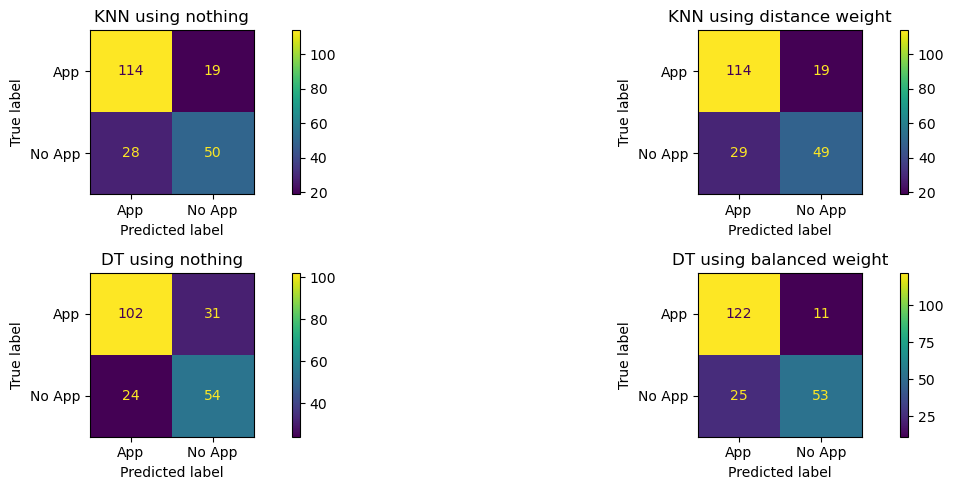

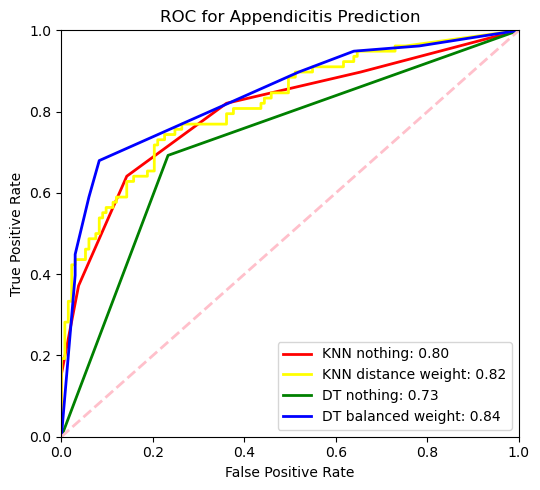

```python
fig = plt.figure(figsize=(14, 5))
roc_curve_values_all = []
for index_c, classifier in enumerate(new_classifiers):
    trained_classifier = classifier.fit(X_train_s, y_train_s)
    y_dash = trained_classifier.predict(X_test_s)
    yN_dash = trained_classifier.predict_proba(X_test_s)

    acc_score = accuracy_score(y_test_s, y_dash)
    confusion = confusion_matrix(y_test_s, y_dash)
    classifier_name = f"{tags[index_c][0]} using {tags[index_c][1]}"
    report = classification_report(y_test_s, y_dash, target_names=["Appendicitis", "No Appendicitis"])
    scores = cross_val_score(classifier, X, y, cv=6, verbose=0, n_jobs=-1)
    fpr, tpr, _ = roc_curve(y_test_s, yN_dash[:, 1])
    roc_auc = roc_auc_score(y_test_s, yN_dash[:, 1])
    print(classifier_name)
    print(f"Accuracy: {acc_score}")
    print(f"Confusion Matrix:\n{confusion}")
    print(f"Report:\n{report}")
    print(f"6x CV Accuracy: {scores.mean():.2f}", end="\n" * 3)
    fg = fig.add_subplot(2, 2, index_c + 1)
    disp = ConfusionMatrixDisplay(confusion, display_labels=["App", "No App"])
    disp.plot(ax=fg)
    plt.title(classifier_name)
    roc_curve_values_all.append([fpr, tpr, roc_auc])
fig.tight_layout()
plt.show()

fig = plt.figure(figsize=(5.5, 5))
for i, roc_curve_value in enumerate(roc_curve_values_all):
    plt.plot(roc_curve_value[0], roc_curve_value[1], color=colors[i], lw=2,
             label=f"{' '.join(tags[i])}: {roc_curve_value[2]:0.2f}")
plt.plot([0, 1], [0, 1], color="pink", lw=2, linestyle="--")
plt.xlim([0.0, 1.0])
plt.ylim([0.0, 1.0])
plt.xlabel("False Positive Rate")
plt.ylabel("True Positive Rate")
plt.title(f"ROC for Appendicitis Prediction")
plt.legend(loc="lower right")
fig.tight_layout()
plt.show()
```

## Task 2

For this part I will only be using the Decision Tree classifier with the tweaks discovered in the study conducted earlier.

I will go through the following strategies and try tweaking the parameters, supposedly getting the best results:

- under-sampling with Random
- combined-sampling with SMOTEENN

```python
def visualisation_v2(classifiers, techniques, row_subplot=1, column_subplot=1, no_iterations=25, visualise=True):
    """
    For every classifier it tests over a number of iterations the given techniques
    :param classifiers: list of classifiers
    :param techniques: list of lists containing object technique and name
    :param row_subplot: int for number of rows in subplot
    :param column_subplot: int for number of columns in subplot
    :param no_iterations: int for number of iterations
    :param visualise: boolean helping to print the data or not
    :return: list of tuples containing the technique name and recall difference between classes
    """
    # Store recall differences and technique names for return
    recall_differences = []

    # loop through classifiers
    for classifier in classifiers:
        if visualise:
            # figure size which contains the subplots
            fig = plt.figure(figsize=(14, 5))
        # accuracies for every iteration of every technique
        acc_scores = [[] for _ in range(len(techniques))]
        # same as before but recall scores
        recall_scores = [[] for _ in range(len(techniques))]
        # same as before but confusion matrices
        confusion_matrices = [[] for _ in range(len(techniques))]
        # all test data which is the same for all of the techniques
        y_tests = []
        # every techniques results for every iteration
        y_dash_all = [[] for _ in range(len(techniques))]

        for _ in range(no_iterations):
            # split the data random every time
            X_train, X_test, y_train, y_test = train_test_split(X_scaled, y, test_size=1 / 3,
                                                                random_state=np.random.randint(1000))
            y_tests.extend(y_test)
            for i, technique in enumerate(techniques):
                # make a copy so it doesn't get mixed up
                X_train_copy, y_train_copy = X_train, y_train
                # the first index has None as first parameter because it doesn't use a technique
                if i != 0:
                    X_train_copy, y_train_copy = technique[0].fit_resample(X_train_copy, y_train_copy)
                trained_classifier = classifier.fit(X_train_copy, y_train_copy)
                y_dash = trained_classifier.predict(X_test)
                y_dash_all[i].extend(y_dash)

                acc_scores[i].append(accuracy_score(y_test, y_dash))
                recall_scores[i].append(recall_score(y_test, y_dash, average=None))
                confusion_matrices[i].append(confusion_matrix(y_test, y_dash))

        for i, technique in enumerate(techniques):
            # Calculate the recall difference between "Appendicitis" and "No Appendicitis"
            appendicitis_recall = np.mean([recall[0] for recall in recall_scores[i]])
            no_appendicitis_recall = np.mean([recall[1] for recall in recall_scores[i]])
            recall_difference = abs(appendicitis_recall - no_appendicitis_recall)
            recall_differences.append((recall_difference, technique[1]))
            if visualise:
                classifier_technique = f"{'DT' if classifier.__class__.__name__[0] == 'D' else 'KNN'} using " + \
                                       technique[1]
                # axis = 0 is not necessary, add every techniques' confusion matrix with each other
                confusion = np.sum(confusion_matrices[i], axis=0)
                print(classifier_technique)
                print(f"Accuracy: {np.mean(acc_scores[i])}")
                print(f"Recall: {appendicitis_recall} (Appendicitis)")
                print(f"Recall: {no_appendicitis_recall} (No Appendicitis)")
                print(f"Confusion Matrix:\n{confusion}", end="\n" * 3)

                fg = fig.add_subplot(row_subplot, column_subplot, i + 1)
                disp = ConfusionMatrixDisplay(confusion, display_labels=["App", "No App"])
                disp.plot(ax=fg)
                plt.title(classifier_technique)

        if visualise:
            fig.tight_layout()
            plt.show()

    recall_differences.sort(key=lambda x: x[0])
    return recall_differences
```

### Under-sampling with Random

```python
dt = DecisionTreeClassifier(class_weight="balanced", criterion="entropy")
```

```python
technique_under_sampling = [
    [None, "Nothing"],
    [RandomUnderSampler(random_state=42), "Random"]
]
```

```
DT using Nothing
Accuracy: 0.7814218009478673
Recall: 0.8255052800871339 (Appendicitis)
Recall: 0.712491495931501 (No Appendicitis)
Confusion Matrix:
[[2662  563]
 [ 590 1460]]


DT using Random
Accuracy: 0.7554502369668247
Recall: 0.742904997546246 (Appendicitis)
Recall: 0.7748658208745794 (No Appendicitis)
Confusion Matrix:
[[2397  828]
 [ 462 1588]]
```

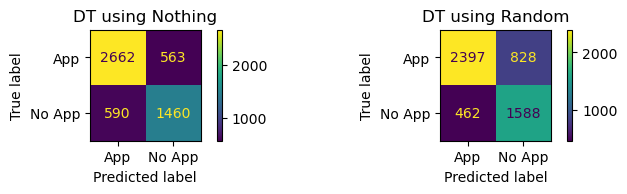

```
[(0.0319608233283335, 'Random'), (0.1130137841556329, 'Nothing')]
```

```python
visualisation_v2([dt], technique_under_sampling, 3, 4)
```

After going through some parameter tuning for the classifier, I found out that this is the best option, and it delivers a very balanced data. The improvements are shown in the recall percentages, of course we lost a little bit of accuracy meanwhile, but not as much as I would've expected. Overall a very good technique that can be used on this dataset.

### Combined-sampling with SMOTEENN

```python
dt = DecisionTreeClassifier(max_depth=7, class_weight="balanced", criterion="entropy")
```

```python
technique_combined_sampling = [
    [None, "Nothing"],
    [SMOTEENN(random_state=42), "SMOTEENN"]
]
```

```
DT using Nothing
Accuracy: 0.7842654028436019
Recall: 0.8390304067964789 (Appendicitis)
Recall: 0.7000534352941954 (No Appendicitis)
Confusion Matrix:
[[2690  518]
 [ 620 1447]]


DT using SMOTEENN
Accuracy: 0.7840758293838864
Recall: 0.8055959675230321 (Appendicitis)
Recall: 0.7510623916209151 (No Appendicitis)
Confusion Matrix:
[[2586  622]
 [ 517 1550]]
```

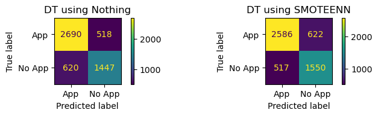

```
[(0.05453357590211694, 'SMOTEENN'), (0.1389769715022835, 'Nothing')]
```

```python
visualisation_v2([dt], technique_combined_sampling, 3, 4)
```

The best data I could get are with these parameter tuning done above, most of the time the recall difference stays at 0.05... but it can happen to have over 0.05. I would say that is not the best for this case, but it does a better job than not using it.

## Task 3

For this part I will only be using the k-Nearest Neighbor classifier with the tweaks discovered in the study conducted earlier.

### Over-sampling with ADASYN

```python
knn = KNeighborsClassifier(n_neighbors=4, weights="distance", metric="euclidean")
```

```python
technique_over_sampling = [
    [None, "Nothing"],
    [ADASYN(n_neighbors=6, random_state=42, sampling_strategy="minority"), "ADASYN"]
]
```

```
KNN using Nothing
Accuracy: 0.7412322274881517
Recall: 0.8241271701035646 (Appendicitis)
Recall: 0.6068812035031561 (No Appendicitis)
Confusion Matrix:
[[2696  577]
 [ 788 1214]]


KNN using ADASYN
Accuracy: 0.7133649289099526
Recall: 0.7097279200263017 (Appendicitis)
Recall: 0.7194732507194168 (No Appendicitis)
Confusion Matrix:
[[2322  951]
 [ 561 1441]]
```

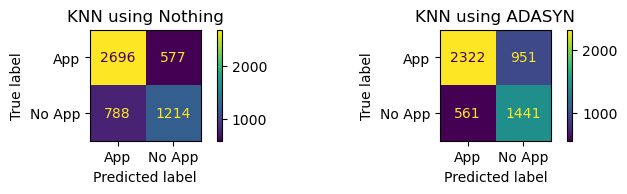

```
[(0.009745330693115117, 'ADASYN'), (0.2172459666004085, 'Nothing')]
```

```python
visualisation_v2([knn], technique_over_sampling, 3, 4)
```

After playing around with the parameters I found that the ones above best fit with this dataset and the only bad part about it is that we lose quite a bit of accuracy, but the balance that we get instead of the accuracy is very good. Usual recall difference goes from 0.001... to 0.03...

```python
knn = KNeighborsClassifier(weights="distance", metric="euclidean")
```

```python
technique_under_sampling = [
    [None, "Nothing"],
    [ClusterCentroids(voting="hard", random_state=42), "ClusterCentroids"]
]
```

```
KNN using Nothing
Accuracy: 0.7448341232227488
Recall: 0.8411625676239833 (Appendicitis)
Recall: 0.591446248087221 (No Appendicitis)
Confusion Matrix:
[[2736  518]
 [ 828 1193]]


KNN using ClusterCentroids
Accuracy: 0.7097630331753554
Recall: 0.7027619824556672 (Appendicitis)
Recall: 0.7210520606453328 (No Appendicitis)
Confusion Matrix:
[[2288  966]
 [ 565 1456]]
```

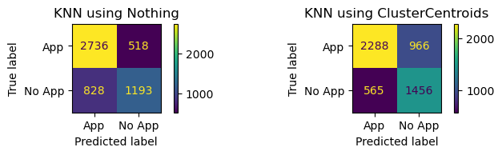

```
[(0.01829007818966555, 'ClusterCentroids'), (0.24971631953676232, 'Nothing')]
```

```python
visualisation_v2([knn], technique_under_sampling, 3, 4)
```

After going through the parameter tweaking I found out that these are the best, because the majority of the time the recall difference is between 0.01... and 0.02... and the accuracy doesn't change that much, is a little bit lower, but better than expected. Also, if you change the classifier parameter to `n_neighbors=4` the minority class gets a better percentage, the problem is that the majority doesn't change that much, therefore the data becomes a little imbalanced again, at least compared to this solution.

### Combined-sampling with SMOTETomek

```python
knn = KNeighborsClassifier(weights="distance", metric="euclidean")
```

```python
technique_combined_sampling = [
    [None, "Nothing"],
    [SMOTETomek(random_state=42), "SMOTETomek"]
]
```

```
KNN using Nothing
Accuracy: 0.7546919431279622
Recall: 0.8402502659397677 (Appendicitis)
Recall: 0.6156981155192648 (No Appendicitis)
Confusion Matrix:
[[2757  527]
 [ 767 1224]]


KNN using SMOTETomek
Accuracy: 0.7374407582938389
Recall: 0.7372086919969305 (Appendicitis)
Recall: 0.7388776154570112 (No Appendicitis)
Confusion Matrix:
[[2420  864]
 [ 521 1470]]
```

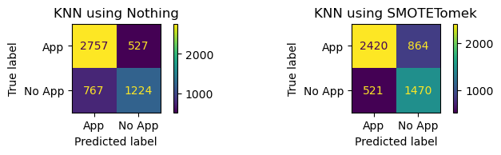

```
[(0.00166892346008074, 'SMOTETomek'), (0.22455215042050292, 'Nothing')]
```

```python
visualisation_v2([knn], technique_combined_sampling, 3, 4)
```

## Task 2 vs Task 3

Results wise, I would say that I've got better results on Task 2 using Decision Tree, the recalls were much higher than in Task 3 where I used k-Nearest Neighbor.

Balanced wise, I would probably say that Task 3 results won, because the techniques used were constantly more balanced than Task 2.

The conclusion is that it depends on what would you like as an outcome, but I would personally choose Task 2 strategies, because the balance difference between the two is not that different after all and the recall scores are higher for Task 2.